# WGCNA Analysis in ALS

compare raw, rbe and sva

Katia de Paiva Lopes/Jack Humphrey Raj Lab Department of Neuroscience Icahn School of Medicine at Mount Sinai NYC, New York

2022-05-03

Input data

Just keep ALS samples

Protein-coding genes only

Regress out technical metrics and RIN

Perform WGCNA

Correlate MEs with: age of onset age at death tissue sex C9orf72 vs non-C9 Motor Onset

NEW FOR REVISIONS Correlate modules with cell-type proportions!

```r
support <-  read_tsv(here::here("data/differential_expression/ALS/ALS_all_differential_expression_support.tsv"))
tech_df <- read_tsv(here::here("data/differential_expression/ALS/ALS_all_differential_expression_tech_metrics.tsv"))

support <- left_join(support,tech_df, by = "sample")

# keeps all 303 ALS samples!
support <- filter(support, disease == "ALS") %>%
  mutate(duration = as.numeric(duration) ) %>%
  mutate(duration = replace_na(duration, median(duration, na.rm = TRUE))) %>%
  mutate(motor_onset = ifelse( motor_onset %in% c("Bulbar", "Limb"), motor_onset, "Other"  )) %>%
  mutate(tissue = case_when(tissue == "Cervical_Spinal_Cord" ~ "CSC",
                            tissue == "Lumbar_Spinal_Cord" ~ "LSC",
                            tissue == "Thoracic_Spinal_Cord" ~ "TSC"
                            )) %>%
  mutate(onset = age - (duration / 12))
# STMN2 splicing
stmn2 <- read_tsv("/Users/Jack/google_drive/Work/Mount_Sinai/STMN2-splicing/data/STMN2_NYGC_RNA_data.tsv")

support$tSTMN2 <- stmn2$tSTMN2_TPM[match(support$sample, stmn2$sample)]
support$tSTMN2[is.na(support$tSTMN2)] <- 0

row.names(support) <- support$sample
# one-hot encode each categorical variable
# model.matrix will one-hot encode any categorical variable
support_onehot <-
  as.data.frame(
    model.matrix(~ disease_c9 + sex + tissue + motor_onset + prep + site, data = support)
    ) %>%
  rownames_to_column(var = "sample") %>%
  left_join(support[, c("sample","rin","age", "onset", "duration", "tSTMN2")], by = "sample") %>%
  select( -"(Intercept)") %>%
  column_to_rownames(var = "sample")
```

## Normalise gene expression data

voom TMM normalisation

```r
if(rerun){
  load(here::here("data/feb_2020/gene_counts_no_tags.RData") )
  load(here::here("data/feb_2020/gene_tpm_no_tags.RData") )

  counts_loc <- genes_counts[,support$sample]
  tpm_loc <- genes_tpm[,support$sample]

  rm(genes_counts)
  #
  #isexpr <- rowSums(cpm(counts_loc)> 1 ) >= 0.5 * ncol(counts_loc)
  # new for 2022
  isexpr <- rowSums(tpm_loc > 0 ) >= 0.5 * ncol(counts_loc)


  # create data structure with only expressed genes
  counts_loc <- counts_loc[isexpr,]

  print( paste0(" * Keeping ", nrow(counts_loc), " expressed genes"))

  # keep only protein-coding genes
  gencode_gene_types <- read_tsv("~/GENCODE/gencode.v30.gene.type.tsv.gz") %>%
    filter(type == "protein_coding") %>%
    mutate(gene_id = gsub("\\.[0-9]+", "", gene_id))
  #library(biomaRt)
  # ensembl <- useMart(biomart="ENSEMBL_MART_ENSEMBL")#, dataset="hsapiens_gene_ensembl")
  #
  # bm_res <-  biomaRt::getBM(attributes=c("ensembl_gene_id","gene_biotype"),
  #                  filters = c("ensembl_gene_id","biotype"),
  #                  values = list(row.names(counts_loc),"protein_coding"),
  #                  mart=ensembl)
  #
  counts_loc <- counts_loc[ row.names(counts_loc) %in% gencode_gene_types$gene_id ,]

  print( paste0(" * Keeping ", nrow(counts_loc), " protein-coding genes"))

  gExpr <- DGEList(counts_loc)
  # Perform TMM normalization
  gExpr <- calcNormFactors(gExpr,method = "TMM")
  # Specify variables to be included in the voom() estimates of
  # uncertainty.
  # Recommend including variables with a small number of categories
  # that explain a substantial amount of variation
  design <- model.matrix( ~ factor(site) + factor(prep), support)

  counts_voom <- voom(gExpr, design = design)$E

  #support$disease <- factor(support$disease, levels = c("Control", "ALS"))

  # mod0 <- model.matrix( ~ 1, support)
 # mod <- model.matrix( ~ age + duration + tissue + motor_onset + disease_c9, support)
  #
  #nsv <- num.sv(counts_voom, mod, method = "be")

  # SVA Network
  #print(paste0("SVA Network with ", nsv, " SVs"))

  #counts_voom_sva <- t(sva_network(counts_voom, nsv))

  # removeBatchEffects
  covariate_df <-
    dplyr::select(support, rin, pct_mrna_bases, median_3prime_bias, median_5prime_bias, pct_chimeras, gPC1, gPC2, gPC3, gPC4, gPC5, pct_ribosomal_bases, pct_intergenic_bases)

  # for Mar 2022
  covariate_df <-
    dplyr::select(support, rin, pct_mrna_bases, prep, gPC1, gPC2, gPC3, gPC4, gPC5) %>%
    mutate(prep = as.numeric(as.factor(prep)) )

  #"~ disease + sex + rin + rin_squared + age + age_squared + prep + site + pct_mrna_bases + gPC1 + gPC2 + gPC3 + gPC4 + gPC5 "

  row.names(covariate_df) <- support$sample

  counts_voom_rbe <- t(removeBatchEffect(counts_voom, batch = support$site, batch2 = support$tissue, covariates = covariate_df ))

  counts_voom <- t(counts_voom)

  # PCA

  pca_voom <- prcomp(counts_voom, center = TRUE, scale. = TRUE)

  #pca_sva <- prcomp(counts_voom_sva, center = TRUE, scale. = TRUE)

  pca_rbe <-  prcomp(counts_voom_rbe, center = TRUE, scale. = TRUE)

  voom_plot <- autoplot(pca_voom, colour = "site", data =support, shape = "prep") + labs(title = "Voom normalised") + theme_jh()

  rbe_plot <- autoplot(pca_rbe, colour = "site", data =support, shape = "prep") + labs(title = "Voom normalised + Site and technical metrics regressed")+ theme_jh()

 # sva_plot <- autoplot(pca_sva, colour = "site",data =support) + labs(title = "Voom + SVA normalised")+ theme_jh()

  print(voom_plot)
  print(rbe_plot)
  #print(sva_plot)

  save(counts_voom_rbe, rbe_plot, file = here::here("data/WGCNA/ALS_SC_Voom_RBE_Mar2022.RData"))
  #save(counts_voom_sva, sva_plot, file = here::here("data/WGCNA/ALS_SC_Voom_SVA.RData"))
  save(counts_voom, voom_plot, file = here::here("data/WGCNA/ALS_SC_Voom_Mar2022.RData"))

}else{
  load(here::here("data/WGCNA/ALS_SC_Voom_RBE_Mar2022.RData"))
 # load(here::here("data/WGCNA/ALS_SC_Voom_SVA.RData"))
 # load(here::here("data/WGCNA/ALS_SC_Voom_Mar2022.RData"))
}
```

March 2022: 16,922 protein coding genes with median TPM > 0

```r
# one function to rule them all
run_WGCNA <- function(datExpr, prefix = "test", deep_split = 4, show_plots = FALSE){
  library(WGCNA)
  library("flashClust")
  nthreads = 8
  allowWGCNAThreads(nthreads)
  # power threshold
  # Choose a set of soft-thresholding powers
  powers = c(c(1:10), seq(from = 12, to=20, by=2))
  # Call the network topology analysis function
  sft = pickSoftThreshold(datExpr, powerVector = powers, verbose = 5)
  # Scale-free topology fit index as a function of the soft-thresholding power

  cex1 = 0.9
  #png(paste0(out_folder, "power_threshold.png"), width = 4, height = 5, res = 300, units = "in")
  if(show_plots){
    pdf(paste0(out_folder, prefix, "_soft_power.pdf"))
    plot.new()
    plot(sft$fitIndices[,1], -sign(sft$fitIndices[,3])*sft$fitIndices[,2],
         xlab="Soft Threshold (power)",ylab="Scale Free Topology Model Fit,signed R^2",type="n",
         main = paste("Scale independence"))
    text(sft$fitIndices[,1], -sign(sft$fitIndices[,3])*sft$fitIndices[,2], labels=powers,cex=cex1,col="red")
    # this line corresponds to using an R^2 cut-off of h
    abline(h=0.90,col="red")
    #dev.off()
  }

  if( is.na(sft$powerEstimate) ){
    print(" * No power found that raises R^2 above 90%. Picking the lowest power above 80%")
    sft$powerEstimate <- sft$fitIndices[ sft$fitIndices$SFT.R.sq >= 0.8,]$Power[1]
  }

  print(paste0(" * Using Power Estimate: ", sft$powerEstimate))

  if(show_plots){
  # Mean connectivity as a function of the soft-thresholding power
    pdf(paste0(out_folder, prefix, "_connectivity.pdf"))
    plot(sft$fitIndices[,1], sft$fitIndices[,5],
         xlab="Soft Threshold (power)",ylab="Mean Connectivity", type="n",
         main = paste("Mean connectivity"))
    text(sft$fitIndices[,1], sft$fitIndices[,5], labels=powers, cex=cex1,col="red")
    dev.off()
  }
  # change based on previous plots
  softPower = sft$powerEstimate

  adjacency <- adjacency(datExpr, power = softPower, type = "signed")
  TOM <- TOMsimilarity(adjacency, TOMType="signed")
  dissTOM <- 1-TOM
  geneTree <- flashClust(as.dist(dissTOM), method="average")
  #png(paste0(out_folder, "TOM_adjacency_signed.png"), width = 20, height = 10, res = 300, units = "in")
  if(show_plots){
     pdf(paste0(out_folder, prefix, "_gene_tree.pdf"))
    plot(geneTree, xlab="", sub="",
         main= "Gene Clustering on TOM-based dissimilarity", labels= FALSE, hang=0.04)
    dev.off()
  }
  # "We like large modules" - Tutorial, so we set the minimum module size relatively high:
  minModuleSize = 50
  # Module identification using dynamic tree cut:
  dynamicMods = cutreeDynamic(dendro = geneTree, distM = dissTOM,
                              deepSplit = deep_split, pamRespectsDendro = FALSE,
                              minClusterSize = minModuleSize);
  clusters_size = data.matrix(table(dynamicMods))
  clusters_size = cbind(rownames(clusters_size),clusters_size)
  colnames(clusters_size) = c("cluster","size")
  #write.table(file = paste0( out_folder, "ALS_SC_WGCNA_sva_clusters_sizes.txt"), x = clusters_size, row.names = FALSE)
  # Convert numeric lables into colors
  dynamicColors = labels2colors(dynamicMods)
  clusters_colors = data.matrix(table(dynamicColors))
  clusters_colors = cbind(rownames(clusters_colors), clusters_colors)
  colnames(clusters_colors) = c("color","size")
  #write.table(file =  paste0( out_folder, "FTD_WGCNA_sva_clusters_colors1.txt"), x = clusters_colors, row.names = F)
  mytable = table(dynamicColors)
  colour_table <- as.data.frame(t(as.matrix(unclass(mytable))))

  n_module_pre <- ncol(colour_table)

  print(paste0( " * Pre-clustering: ", n_module_pre," modules!") )

  hist(colour_table[1,])
  if(show_plots){
     pdf(paste0(out_folder, prefix, "_color_dendro_pre_filter.pdf"))
    plotDendroAndColors(geneTree, dynamicColors, "Dynamic Tree Cut",
                        dendroLabels = FALSE, hang = 0.03,
                        addGuide = TRUE, guideHang = 0.05,
                        main = "Gene dendrogram and module colors")
    dev.off()
  }
  # Calculate eigengenes
  MEList = moduleEigengenes(datExpr, colors = dynamicColors)
  MEs = MEList$eigengenes
  # Calculate dissimilarity of module eigengenes
  MEDiss = 1-cor(MEs)
  # Cluster module eigengenes
  METree = hclust(as.dist(MEDiss), method = "average")
  # Plot the result
  #sizeGrWindow(7, 6)
  #png(paste0(out_folder, "Tree_eigengenes.png"), width = 12, height = 8, res = 300, units = "in")

  #We choose a height cut of 0.25, corresponding to correlation of 0.75, to merge
  MEDissThres = 0.25

  if(show_plots){
    pdf(paste0(out_folder, prefix, "_clistering.pdf"))
    plot(METree, main = "Clustering of module eigengenes",
         xlab = "", sub = "")

    # Plot the cut line into the dendrogram
    abline(h=MEDissThres, col = "red")
    dev.off()
  }
  ## MERGE MODULES
  # Call an automatic merging function
  merge <- mergeCloseModules(datExpr, dynamicColors, cutHeight = MEDissThres, verbose = 3)
  # The merged module colors
  mergedColors = merge$colors;
  # Eigengenes of the new merged modules:
  mergedMEs = merge$newMEs
  #sizeGrWindow(12, 9)
  #png(paste0(out_folder, "Merge_modules.png"), width = 16, height = 8, res = 300, units = "in")
  if(show_plots){
  pdf(paste0(out_folder, prefix, "_color_dendro_post_filter.pdf"))
  plotDendroAndColors(geneTree, cbind(dynamicColors, mergedColors),
                      c("Dynamic Tree Cut", "Merged dynamic"),
                      dendroLabels = FALSE, hang = 0.03,
                      addGuide = TRUE, guideHang = 0.05)
  dev.off()
  }
  n_module_post <- length(unique(mergedColors))

  print(paste0( " * Post-clustering:", n_module_post," modules!") )


  moduleColors <- mergedColors
  # Construct numerical labels corresponding to the colors
  colorOrder <- c("grey", standardColors(50));
  moduleLabels <- match(moduleColors, colorOrder)-1;
  MEs = mergedMEs

  gene_ids <- colnames(datExpr)

  gene_modules <- as.data.frame(cbind(gene_ids, moduleColors))
  gene_modules <- gene_modules %>% select(gene = gene_ids, module = moduleColors)
  gene_modules$genename <- gene_meta$genename[ match(gene_modules$gene, gene_meta$geneid)]

  # Save module colors and labels for use in subsequent parts
  save(MEs, mergedMEs, moduleColors, geneTree, gene_modules, file = paste0(out_folder, prefix, "_WGCNA_eigengenes.RData"))
  save(x = adjacency, file = paste0(out_folder, prefix, "_adjacency.Rdata"))

}


# test_data <- t(counts_voom)[1:10, 1:5000]
# run_WGCNA(test_data, prefix = "test")
#
# prefix <- "test"
# load(paste0(out_folder, prefix, "_WGCNA_eigengenes.RData"))

if(rerun){
  # default deepSplit is 4
  #run_WGCNA(counts_voom, prefix = "model1")
 # run_WGCNA(counts_voom_rbe, prefix = "model2", show_plots = TRUE)

  run_WGCNA(counts_voom_rbe, prefix = "model2a", show_plots = TRUE)

  #run_WGCNA(counts_voom_sva, prefix = "model3")
  # run_WGCNA(counts_voom_sva, prefix = "model4", deep_split = 3)
  # run_WGCNA(counts_voom_rbe, prefix = "model5", deep_split = 3)
}
```

## Trait associations - sel

Correlate modules with clinical traits Overlap with cell type markers Overlap with glial activation lists Overlap with DEGs from the ALS vs Control models.

```r
# correlate traits in support_onehot with each module (spearman)
# report correlations and P-values
trait_assoc <- function(model, plot_return = NULL, return_object = FALSE, support_loc = support_onehot){
  require(WGCNA)
  load(paste0(out_folder, model, "_WGCNA_eigengenes.RData"))

  support_mes <- MEs %>% rownames_to_column(var = 'sample') %>%
  left_join(support, by = "sample")

  message(paste0(" * ", ncol(MEs), " Modules!" ) )

  #nGenes = ncol(datExpr)
  nSamples = nrow(MEs)

  moduleTraitCor = cor(MEs, support_loc, use = "p", method = "spearman")
  moduleTraitPvalue = corPvalueStudent(moduleTraitCor, nSamples)

  module_trait_res <-
  left_join(
    moduleTraitCor %>%
      as.data.frame() %>%
      rownames_to_column(var = "module") %>%
      tidyr::gather( key = "trait", value  = "correlation", -module),

    moduleTraitPvalue %>%
      as.data.frame() %>%
      rownames_to_column(var = "module") %>%
      tidyr::gather( key = "trait", value  = "p.value", -module),
    by = c("module", "trait"))


  all_colours <- unique(moduleColors)
  names(all_colours) <- all_colours

  module_trait_res <-
    module_trait_res  %>%
    mutate( module = gsub("ME", "", module) )

  return(module_trait_res)
}

# plotting module eigengenes
module_trait_plot <- function(m, trait, xlabel = "", traits = support){
  stopifnot(trait %in% colnames(traits))
  if( ! "sample" %in% names(traits) ){
    traits <- rownames_to_column(traits, var = "sample")
  }
  module_eigengenes <- MEs %>%
    rownames_to_column(var = "sample") %>%
    tidyr::gather( key = "module", value = "ME", -sample) %>%
    left_join(traits, by = "sample") %>%
    rename(module_name = module) %>%
    left_join(colour_df, by = "module_name") %>%
    filter(module_name == m)

  if( is.numeric(module_eigengenes[[trait]] )){
    mode <- "cont"
  }else{
    mode <- "categ"
  }

  stopifnot(nrow(module_eigengenes) > 0)

  plot <-
      module_eigengenes %>%
      ggplot( aes_string( x = trait , y = "ME") ) +
      theme_classic() +
      labs( x = xlabel, y = m) +
    theme(axis.text = element_text(colour = "black"),
          axis.title.y = element_text(colour = "black", angle = 0, size =12, face = "bold", vjust = 0.5),
          axis.ticks = element_line(colour = "black")
    #panel.border = element_rect(size = 0.6, colour = "black", fill = NA),
    )


    if(mode == "cont"){

      plot <- plot +
        geom_point(colour = "black", size = 1) +
        geom_point(aes(colour = module_name), size = 0.8) +
        geom_smooth(method = "lm", colour = "black", formula = y ~ x) +
        scale_colour_manual(values = module_colour_order ) +
        guides(colour = "none") +
        stat_cor(aes(label = ..r.label..), method = "spearman", label.x.npc = 0.5, label.y.npc =  0.15)

      # if(m == "M18"){
      #   plot <- plot +
      #     geom_point(colour = "black", size = 1) +
      #     geom_point(colour = "white", size = 0.8)
      # }

    }

    if(mode == "categ"){
      plot <- plot +
        geom_jitter(width = 0.2, size = 0.5) +
        geom_boxplot(aes(fill = module), outlier.colour = NA, notch = TRUE, colour = "black") +
        scale_fill_manual(values = module_colour_order ) +
        guides(fill = "none") +
        ggpubr::stat_compare_means()

    }
    return(plot)
}


module_go <- function(model, rerun = FALSE, term_set = "KEGG"){
  load(paste0(out_folder, model, "_WGCNA_eigengenes.RData"))

  gene_modules %>% group_by(module) %>% tally() %>% arrange( desc(n)) %>%
    ggplot(aes(x = n)) + geom_histogram()

  module_go <-
    gene_modules %>%
    #filter( !module %in% c("blue","turquoise")) %>%
    mutate(gene = as.character(gene), module = as.character(module) ) %>%
    split(.$module) %>% purrr::map("genename")

  module_file <- paste0(out_folder, model, "_WGCNA_module_", term_set, ".tsv")

  if(rerun | !file.exists(module_file)){
    module_gprofile <- gprofiler2::gost(module_go, organism = "hsapiens", sources = term_set )$result
    module_gprofile$parents <- NULL
    write_tsv(module_gprofile, path = module_file )
  }else{
    module_gprofile <- read_tsv(module_file)
  }

  n_modules_w_kegg <- module_gprofile %>% group_by(query) %>% tally() %>% nrow()

  n_modules <- ncol(MEs)

  print(paste0(" * N modules: ", n_modules))

  print(paste0(" * N modules with ", term_set, " terms: ", n_modules_w_kegg))


  module_gprofile %>% select(module = query, term = term_name, p = p_value, query_size, intersection_size, precision) %>% filter( intersection_size >= 10 ) %>%
    mutate( p = signif(p, digits = 2), precision = signif(precision, digits = 2) )

}

## use lists of marker genes for fisher exact test overlaps with modules
marker_gene_enrichment <- function(model, set = "kelley"){
  load(paste0(out_folder, model, "_WGCNA_eigengenes.RData"))

  module_gene_list <- split(gene_modules, gene_modules$module) %>% purrr::map("genename")
  stopifnot(set %in% c("kelley", "activation", "nxp", "DEGs", "Panglaodb", "mathys"))
  markers <- c()
  # marker_df is empty tibble - grow for each set to give annotations and order to data
  marker_df <- tibble()

  if( "kelley" %in% set){
    load(here::here("data/markers/kelley_markers.RData"))
    markers <- c(markers, kelley)
    kelley_df <- tibble(set = "Cell-type markers\n(Kelley)", marker = names(kelley) )
    marker_df <- c(marker_df, list(kelley_df) )
  }
  if( "nxp" %in% set){
    load(here::here("data/misc/neuroexpresso_spinal_cord_human.RData"))
    markers <- c(nxp, markers)
    nxp_df <- tibble(set = "Cell-type markers\n(Neuroexpresso)", marker = names(nxp) )
    marker_df <- c(marker_df, list(nxp_df) )
  }

  if( "activation" %in% set){
    load(here::here("data/markers/activation_markers.RData"))
    #sets <- c( "Disease-associated microglia", "Disease-associated astrocytes", "Reactive astrocytes - MCAO", "Reactive astrocytes - LPS", "Plaque-induced genes")
    activation_markers <- activation_sets#[ sets]

    markers <- c(activation_markers, markers)
    activation_df <- tibble(set = "Glial activation", marker = names(activation_markers) )
    activation_df$marker <- factor(activation_df$marker)#, levels = sets)
    marker_df <- c(marker_df, list(activation_df))
  }
  if( "mathys" %in% set){
    mathys_conversion_table <- data.frame(
      short = c("Ast","End", "Mic", "Ex", "Oli", "Per" ),
      long = c("Astrocytes", "Endothelial", "Microglia", "Neurons", "Oligos", "Pericytes"),
      mono = c("A","E","M","N","O","P")
    )
    load(here::here("data/markers/Mathys_single_nucleus.RData"))
    names(mathys) <- mathys_conversion_table$long[ match(names(mathys), mathys_conversion_table$short)]
    mathys <- mathys[ !is.na(names(mathys))]
    markers <- c(mathys, markers)
    mathys_df <- tibble(set = "Mathys", marker = names(mathys))
    marker_df <- c(marker_df, list(mathys_df) )

  }
  if( "Panglaodb" %in% set){
    load( here::here("data/Panglaodb/PanglaoDB_markers_list.RData") )
    pg_list <- pg_list[ c("Endothelial cells", "Ependymal cells", "Microglia", "Neurons", "Oligodendrocytes", "Pericytes", "Astrocytes")]
    markers <- c(pg_list, markers)

    pg_df <- tibble(set = "Cell-type markers\n(Panglaodb)", marker = names(pg_list) )
    marker_df <-  c(marker_df, list(pg_df))

  }

  if( "DEGs" %in% set){
    load(file = here::here("data/differential_expression/ALS/ALS_Spinal_Cord_de_res_Mar2022.RData"))
    deg_markers <- de_res_final %>%
      map_df( ~{.x %>%
          filter(adj_p_val < 0.05) %>% # abs(log_fc) > 1) %>%
          mutate(direction = ifelse(log_fc > 0, yes = "Upregulated in ALS", no = "Downregulated in ALS" ) ) %>%
          select(direction, genename) }, .id = "set"
      ) %>%
      mutate(direction = factor(direction, levels = c("Upregulated in ALS", "Downregulated in ALS"))) %>%
      split(.$direction) %>%
    map(~{unique(.x$genename) })

    deg_df <- tibble(set = "DEGs", marker = names(deg_markers))

    markers <- c(deg_markers, markers)
    marker_df <- c(marker_df, list(deg_df) )
  }

  marker_enrich_df <-
    purrr::map_df( module_gene_list, ~{
      mod <- .x
      purrr::map_df( markers, ~{
        mark <- .x
        markerEnrichment(module = mod, marker = mark, universe = nrow(gene_modules) )
      }, .id = "marker")
    }, .id = "module") %>%
    left_join( bind_rows(marker_df), by = "marker")


  marker_enrich_df$padj <- p.adjust(p = marker_enrich_df$p.value, method = "bonferroni")
  return(marker_enrich_df)
}

# plot_marker_enrich <- function(marker_enrich_df){
#   marker_enrich_df$module <- paste0(marker_enrich_df$module, " (", marker_enrich_df$module_length, ")")
#   marker_enrich_df$marker <- paste0(marker_enrich_df$marker, "\n(", marker_enrich_df$marker_length, ")")
#
#   marker_enrich_df %>%
#     #mutate( ratio = ifelse(padj < 0.05, ratio, NA)) %>%
#     filter( padj < 0.05) %>%
#     ggplot( aes(x = marker, y = module)) +
#     geom_tile( aes(fill = log(ratio) )) +
#     geom_text( aes( label = signif(ratio,digits = 3) )) +
#     scale_fill_distiller("log(odds ratio)", type = "seq", palette = 8, direction = 1, na.value = NA) + #, limits = c(1,4)) +
#     xlab("") + ylab("") + theme_classic() +
#     labs(title = "Marker gene enrichment") +
#     scale_x_discrete(expand = c(0,0)) +
#     scale_y_discrete(expand = c(0,0)) +
#     theme(axis.text.x = element_text(angle = 45, hjust = 1) ) +
#     facet_wrap(~set, scales = "free_x", strip.position = "bottom") +
#     theme(strip.background = element_blank(), strip.placement = "outside", strip.text = element_text(face = "bold"))
# }


trait_plot <- function(res, traits = trait_df$trait_label){
  # traits
  res %>%
  mutate(padj = p.adjust(p.value, method = "bonferroni")) %>%
  mutate(trait_label = factor(trait_label, levels = rev(traits) )) %>%
  mutate(label = ifelse(padj < 0.05, "*", "")) %>%
  mutate(module = factor(module, levels = module_colour_order )) %>%
  ggplot(aes(x = module, y = trait_label, fill = correlation)) +
  geom_tile(colour = "black") +
  geom_text(aes(label = label), nudge_y = -0.2, colour = "white") +
  scale_fill_distiller(palette = "RdBu", na.value = "white") +
  scale_x_discrete(expand=c(0,0)) +
  scale_y_discrete(expand=c(0,0)) +
  theme_classic() +
  labs(x = "", y = "") +
  facet_wrap(~1) +
  theme(
    plot.margin = margin(),
    axis.line = element_blank(),
    strip.text = element_blank(),
    panel.border = element_rect(size = 0.6, colour = "black", fill = NA),
    axis.text.x = element_blank(), axis.text.y = element_text(colour = "black"),axis.ticks.x = element_blank(),
    legend.key.size = unit(0.25, 'cm'), legend.title = element_text(size = 5), legend.text = element_text(size =5)
    )
}

marker_plot <- function(res, marker_levels = NULL){
  # markers
  if( !is.null(marker_levels) ) {
    res$marker <- fct_rev(factor(res$marker, levels = marker_levels))
  }else{
    res$marker <- fct_rev(as.factor(res$marker) )
  }

  res %>%
  arrange(desc(marker)) %>%
  mutate(label = ifelse(padj < 0.05, "*", "")) %>%
  mutate(p.value = ifelse(p.value < 1e-16, 1e-16, p.value)) %>% # threshold P values on 1e-16
  mutate(module = factor(module, levels = module_colour_order)) %>%
  ggplot(aes(x = module, y = marker, fill = -log10(p.value))) +
  geom_tile(colour = "black") +
  geom_text(aes(label = label), nudge_y = -0.2, colour = "white") +
  #scale_fill_distiller(palette = "RdBu", na.value = "white") +
  scale_x_discrete(expand=c(0,0)) +
  scale_y_discrete(expand=c(0,0)) +
  theme_classic() +
  scale_fill_gradient(expression(-log[10]~p-value), low = "white", high = "darkblue") +
  labs(x = "", y = "") +
  facet_wrap(~1) +
  theme(
    plot.margin = margin(),
    axis.line = element_blank(),
    strip.text = element_blank(),
    panel.border = element_rect(size = 0.6, colour = "black", fill = NA),
    axis.text.x = element_blank(), axis.text.y = element_text(colour = "black"),axis.ticks.x = element_blank(),
    legend.key.size = unit(0.25, 'cm'), legend.title = element_text(size = 5), legend.text = element_text(size =5)
    )

}
```

March 2022 - median TPM > 0, regressinng out prep, pct_mrna, rin, site, gPCs - 23 modules

```r
# load model
model <- "model2a"
load(paste0(out_folder, model, "_WGCNA_eigengenes.RData"))
# name modules by size

module_names <- enframe(table(moduleColors), name = "module", value = "n") %>%
  arrange(n) %>%
  mutate(module_name = paste0("M", 1:nrow(.)))

# cluster MEs by correlation
names(MEs) <- module_names$module_name[ match( gsub("ME", "", names(MEs)), module_names$module )]

module_eigengene_supp_table <- MEs %>%
  rownames_to_column(var  = "sample")

module_eigengene_supp_table
```

| sample | M12 | M16 | M1 | M3 | M5 | M8 | M6 | M19 | M22 | M20 | M11 | M9 | M15 | M4 | M13 | M18 | M7 | M17 | M14 | M23 | M21 | M10 | M2 |
| --- | --- | --- | --- | --- | --- | --- | --- | --- | --- | --- | --- | --- | --- | --- | --- | --- | --- | --- | --- | --- | --- | --- | --- |
| CGND-HRA-01288-2 | -0.0540881489 | 0.0260665888 | 6.301270e-02 | 0.0270947067 | -2.307044e-02 | -4.637439e-02 | 2.741009e-03 | 0.0729269971 | 0.0783226683 | 0.0037482322 | -0.0594820257 | 1.668621e-02 | -0.0026303457 | -0.0343953912 | -0.0181332745 | 0.0431388369 | 6.514269e-02 | 6.462216e-02 | 3.655475e-02 | -4.933093e-02 | -0.0587187046 | 0.0509962385 | -0.0277543117 |
| CGND-HRA-00278-2 | -0.0521780100 | 0.0024855328 | -5.447575e-02 | -0.0385991342 | 1.095405e-02 | -3.376531e-02 | 1.071790e-05 | 0.1056761375 | 0.0855403584 | 0.0530148649 | 0.0248929751 | -3.948491e-02 | 0.0003724346 | -0.0504402126 | 0.0124882297 | -0.0068144295 | 2.720619e-02 | 6.664833e-02 | -1.373697e-02 | -1.035455e-01 | -0.0876006506 | 0.0732665517 | 0.0139340241 |
| CGND-HRA-01351-2 | 0.0030338291 | 0.0566320512 | 7.903723e-03 | 0.0532329417 | 5.607041e-02 | 4.480686e-02 | 9.489095e-02 | -0.0004007179 | 0.0583264857 | 0.0325458570 | 0.1049398485 | 5.729803e-02 | 0.0825883169 | 0.0062165721 | -0.0846881728 | -0.0255820174 | -2.798525e-02 | -7.890256e-02 | -7.171443e-02 | -3.637060e-02 | -0.0869849834 | -0.0339734280 | -0.0901246218 |
| CGND-HRA-00041 | -0.0421573170 | -0.0617321852 | 8.738690e-02 | 0.0401572089 | -4.732725e-02 | -7.204619e-02 | -4.753543e-02 | -0.0214167310 | -0.0620714115 | -0.0866780453 | -0.0873700764 | 4.325852e-02 | -0.0161400886 | 0.0687053410 | 0.0625729596 | 0.1155926759 | 1.025297e-01 | 3.177874e-02 | 9.612600e-02 | 1.970985e-02 | 0.0702722159 | -0.1089581805 | -0.0591714586 |
| CGND-HRA-00043 | 0.0307496352 | -0.0266088044 | -7.474883e-02 | -0.0361543861 | 2.007448e-02 | 3.015030e-02 | -3.926689e-02 | -0.0024962249 | -0.0556530583 | -0.0389141633 | -0.0219300741 | -2.037085e-02 | -0.0051800446 | 0.0474925147 | 0.0765559262 | -0.0407730499 | 1.878161e-02 | -4.918260e-02 | -3.627940e-02 | 1.902332e-02 | 0.0477573602 | -0.0143218686 | 0.0527778801 |
| CGND-HRA-00045 | 0.0067915048 | -0.1216827492 | -1.367879e-01 | -0.1306488418 | -1.934573e-03 | -3.520137e-03 | -1.110695e-01 | -0.0208680069 | -0.1079183847 | 0.1128947768 | -0.0449145389 | -5.323121e-02 | -0.0090853801 | 0.0286114169 | 0.1471898590 | -0.0691445951 | -6.221101e-03 | -1.378788e-01 | -6.763477e-02 | 4.010710e-02 | 0.0905731339 | -0.0913156225 | 0.0472718764 |
| CGND-HRA-00047 | -0.0006043724 | -0.0323410126 | -1.100269e-02 | -0.0362394411 | -7.697789e-02 | -3.429835e-02 | -6.823962e-02 | -0.0375255218 | -0.0645842118 | -0.0924653561 | -0.0243403595 | 6.227728e-02 | -0.0173541010 | 0.0320030051 | 0.0262336113 | 0.0558227725 | 2.186272e-04 | 3.682561e-02 | 9.902337e-02 | 2.546119e-02 | 0.0606414654 | -0.0032027993 | 0.0597889166 |
| CGND-HRA-00048 | 0.0591944869 | 0.0083270157 | 3.114761e-02 | -0.0529786678 | -8.988108e-02 | -8.628414e-03 | -4.815268e-02 | -0.1356965412 | -0.0875110897 | 0.0323960589 | -0.0451708741 | 1.435979e-02 | -0.0345059513 | -0.0177557512 | -0.0705659236 | -0.0316086514 | 2.247077e-03 | 1.918007e-03 | 3.929168e-02 | 8.731505e-02 | 0.0320966839 | -0.0007592865 | -0.0054813131 |
| CGND-HRA-00227 | 0.0214142893 | 0.0257877088 | 3.872516e-03 | 0.0480422094 | 4.807408e-02 | 7.780308e-02 | 7.322815e-02 | -0.0524653354 | 0.0058576666 | 0.0401956689 | 0.0313038051 | -2.444563e-02 | -0.0492756999 | -0.0272864322 | -0.0843722479 | -0.0319282167 | -8.751024e-02 | -7.174628e-02 | -6.580530e-02 | 2.216380e-02 | -0.0325260960 | -0.0476762778 | -0.0776328993 |
| CGND-HRA-00228 | 0.0106056852 | -0.0280764183 | -2.329007e-02 | 0.0185908605 | 4.792758e-02 | 9.732657e-02 | 4.049347e-02 | -0.0912749822 | -0.0647124451 | 0.0141405918 | 0.0615090546 | 1.966334e-02 | -0.0175294135 | 0.0330108503 | -0.0573265409 | -0.0345137562 | -7.193245e-02 | -1.315451e-01 | -5.961744e-02 | 7.630029e-02 | 0.0264284542 | -0.0809066630 | -0.0720741561 |

[output cut: 293 more lines]

```r
write_tsv(module_eigengene_supp_table, file = "ALS_SC/tables/networks/networks_eigengenes.tsv")

MEDiss = 1-cor(MEs)
# Cluster module eigengenes
module_clust = hclust(as.dist(MEDiss), method = "average")

#module_clust <- hclust(dist(1 - cor(MEs)))

module_name_order <- names(MEs)[module_clust$order]
module_colour_order <- module_names$module[ match(module_name_order, module_names$module_name)]

names(module_colour_order) <- module_name_order

save( module_colour_order, module_names, file = here::here(paste0("data/WGCNA/ALS_signed_deep_split_4/",model, "_WGCNA_module_names.RData")))

# write out gene modules
gene_module_df <- gene_modules %>% left_join( module_names, by = "module") %>%
  select(module, module_name, genename, ensemblid = gene) %>%
  arrange(module_name)

write_tsv(gene_module_df, here::here("ALS_SC/tables/networks/networks_module_genes.tsv") )

eigengene_df <- MEs %>% rownames_to_column(var = 'sample')

# use de-identified sample IDs
sample_deid <- read_tsv(here::here("ALS_SC/tables/all_samples_used_in_study.tsv"))

eigengene_df$sample_deid <- sample_deid$rna_id[match(eigengene_df$sample, sample_deid$external_sample_id)]

eigengene_df <- dplyr::select(eigengene_df, sample_id = sample_deid, starts_with("M") )

write_tsv(eigengene_df, here::here("ALS_SC/tables/networks/networks_eigengenes.tsv") )
```

Module membership

```r
load(here::here("data/WGCNA/ALS_SC_Voom_RBE_Mar2022.RData"))

geneModuleMembership = as.data.frame(cor(counts_voom_rbe, MEs, use = "p"))
MMPvalue = as.data.frame(WGCNA::corPvalueStudent(as.matrix(geneModuleMembership), nrow(counts_voom_rbe)));

save(geneModuleMembership, MMPvalue, file =  here::here("data/WGCNA/module_membership.RData"))
```

```r
## colours
colour_df <-
  tibble( module = module_colour_order, module_name = names(module_colour_order) ) %>%
  mutate(module = factor(module, levels = module_colour_order)) %>%
  mutate(module_name = factor(module_name, levels = names(module_colour_order))) %>%
  mutate(module_order = as.numeric(module))

colour_plot <-
  colour_df %>%
  ggplot(aes(x = module_name, y = 1)) + geom_tile(aes(fill = module_name) ) +
  scale_fill_manual( values = module_colour_order) + #theme_void() +
  guides(fill = FALSE) +
  scale_y_continuous(expand = c(0,0)) +
  scale_x_discrete(expand=c(0,0), position = "top") +
  facet_wrap(~1) +
  labs(x = "", y = "") +
  theme_void() +
  theme(axis.ticks = element_blank(),
        strip.text = element_blank(),
        strip.background = element_blank(),strip.placement = "inside",
        panel.border = element_rect(size = 0.6, colour = "black", fill = NA),
        axis.text.y = element_blank(),
        axis.text.x.top = element_text(angle = 90,hjust = 0.5, vjust = 0.5, colour = "black", size = 8,margin = margin() ),
        plot.margin = margin(b = 5, t = 0, unit = "pt") )

# module size plot
size_plot <- gene_module_df %>%
  group_by(module_name) %>% tally() %>%
  inner_join(colour_df) %>%
  mutate(module_name = factor(module_name, levels = names(module_colour_order) )) %>%
  ggplot(aes(x = module_name, y = 1)) +
  geom_tile(aes(fill = n) )  +
  #scale_fill_manual( values = module_colour_order) + #theme_void() +
  #guides(fill = FALSE) +
  scale_fill_gradient(low = "white", high = "black") +
  scale_y_continuous(expand = c(0,0)) +
  scale_x_discrete(expand=c(0,0), position = "top") +
  facet_wrap(~1) +
  labs(x = "", y = "", fill = "Module size") +
  theme_void() +
  theme(axis.ticks = element_blank(),
        strip.text = element_blank(),
        axis.text.x.top = element_blank(),
        strip.background = element_blank(),strip.placement = "inside",
        panel.border = element_rect(size = 0.6, colour = "black", fill = NA),
        axis.text.y = element_blank(),
         legend.key.size = unit(0.25, 'cm'),
        legend.title = element_text(size = 5),
        legend.text = element_text(size =5),
        #axis.text.x.top = element_text(angle = 90,hjust = 0.5, vjust = 0.5, colour = "black", size = 8,margin = margin() ),
        plot.margin = margin(b = 5, t = 0, unit = "pt") )


## dendrogram

dhc <- as.dendrogram(module_clust)
# Rectangular lines
ddata <- dendro_data(dhc, type = "rectangle")

dendro_plot <-
  ggplot(segment(ddata)) +
  geom_segment(aes(x = x, y = y, xend = xend, yend = yend)) +
  #geom_tile(data = colour_df, aes(x = 1:nrow(colour_df), y = 0, fill = module), colour = "black", size = 0.5 ) +
  scale_fill_manual( values = module_colour_order) + theme_void() +
  #ylim(-1,5) +
  scale_x_continuous(expand = c(0, 0), limits = c(0.5, nrow(colour_df) + 0.5 )) +
  guides(fill = FALSE) +
  theme(plot.margin = margin() )


#marker_me_nxp <- marker_gene_enrichment("model2", set = c("nxp"))
#marker_me_panglao <- marker_gene_enrichment("model2", set = c("Panglaodb"))


marker_me_kelley <- marker_gene_enrichment(model, set = c("kelley"))

marker_kelley_df <- marker_me_kelley %>%
  left_join(module_names, by = "module") %>%
  mutate( set = "Kelley et al. 2018") %>%
  select(module, module_name, marker, module_length, marker_length, overlap, ratio, p.value, padj ) %>%
  arrange(padj)

write_tsv(marker_kelley_df, here::here("ALS_SC/tables/networks/networks_kelley_markers_enrich.tsv") )

marker_me_mathys <- marker_gene_enrichment(model, set = c("mathys"))

marker_mathys_df <- marker_me_mathys %>%
  left_join(module_names, by = "module") %>%
  mutate( set = "Mathys et al. 2020") %>%
  select(module, module_name, marker, module_length, marker_length, overlap, ratio, p.value, padj ) %>%
  arrange(padj)

write_tsv(marker_mathys_df, here::here("ALS_SC/tables/networks/networks_mathys_markers_enrich.tsv") )




trait_df <- tibble(
  trait = c("age", "onset", "duration", "motor_onsetLimb", "sexMale", "disease_c9sALS", "tSTMN2"),
  trait_label = c("Age at death", "Age at onset", "Disease duration", "Limb vs Bulbar onset", "Sex", "C9orf72", "tSTMN2")
)

trait_me <-
  trait_assoc(model, return_object = TRUE) %>%
  left_join(trait_df, by = "trait") %>%
  left_join(module_names, by = "module") %>%
  filter( !is.na(trait_label)  ) %>%
  mutate(padj = p.adjust(p.value, method = "bonferroni")) %>%
  select(module, module_name, n, trait_label, correlation, p.value, padj) %>%
  arrange(padj)

trait_me$n <-  as.vector(trait_me$n)

write_tsv(trait_me, here::here("ALS_SC/tables/networks/networks_trait_cor.tsv") )


m2_trait_plot <- trait_plot(trait_me) #, traits = c("duration", "motor_onsetLimb", "sexMale", "disease_c9sALS", "tSTMN2"))


m2_marker_plot <- marker_plot(marker_me_kelley)

#m2_marker_plot_panglao <- marker_plot(marker_me_panglao)

deg_me <- marker_gene_enrichment(model, set = c( "DEGs"))

deg_me_df <- deg_me %>%
  left_join(module_names, by = "module") %>%
  #mutate( set = "") %>%
  select(module, module_name, marker, module_length, marker_length, overlap, ratio, p.value, padj ) %>%
  arrange(padj)

write_tsv(deg_me_df, here::here("ALS_SC/tables/networks/networks_deg_enrich.tsv") )


m2_deg_plot <- marker_plot(deg_me, marker_levels = c("Upregulated in ALS", "Downregulated in ALS"))

marker_me_activation <- marker_gene_enrichment(model, set = c("activation"))

activation_me_df <- marker_me_activation %>%
  left_join(module_names, by = "module") %>%
  #mutate( set = "") %>%
  select(module, module_name, marker, module_length, marker_length, overlap, ratio, p.value, padj ) %>%
  arrange(padj)

write_tsv(activation_me_df, here::here("ALS_SC/tables/networks/networks_activation_enrich.tsv") )

# for supplement
all_marker_enrich_df <- bind_rows(marker_mathys_df, activation_me_df)
write_tsv(all_marker_enrich_df , here::here("ALS_SC/tables/networks/networks_celltype_activation_enrich.tsv") )


# new for 2022 - marker enrichment using Mathys top 100

marker_me_mathys <- marker_gene_enrichment(model, set = c("mathys"))
m2_mathys_plot <- marker_plot(marker_me_mathys)

m2_activation_plot <- marker_plot(marker_me_activation) #marker_levels = c( "Disease-associated microglia", "Disease-associated astrocytes", "Reactive astrocytes - MCAO", "Reactive astrocytes - LPS", "Plaque-induced genes") )
```

Gene Ontology

curate modules into consensus pathways

```r
# kegg_res <- module_go("model2", term_set = "KEGG", rerun = FALSE) %>% left_join(colour_df) %>%
#   arrange(module_order)

go_res <- module_go("model2a", term_set = "GO:BP", rerun = FALSE) %>% left_join(colour_df) %>%
  arrange(module_order) %>%
  mutate(q = p.adjust(p, method = "bonferroni"))
```

```
## [1] " * N modules: 23"
## [1] " * N modules with GO:BP terms: 22"
```

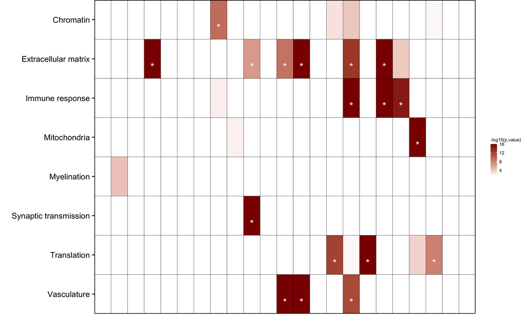

```r
go_res_df <-
  go_res %>%
  left_join(module_names, by = c("module", "module_name") )%>%
  #mutate( set = "") %>%
  select(module, module_name, go_term = term, n = query_size, overlap = intersection_size, precision, p.value = p, padj = q  ) %>%
  arrange(padj)

write_tsv(go_res_df, here::here("ALS_SC/tables/networks/networks_go_enrich.tsv") )



go_grep <- function(res, strings, module_order = module_colour_order){
  p_df <- tibble( module = module_colour_order )
  q_df <- tibble( module = module_colour_order )
  for( i in 1:length(strings) ){
    hit_modules <- filter(res, grepl(strings[i], res$term ) ) %>% group_by(module) %>%
      summarise( q = min(q), p = min(p) )

    p_df[, names(strings)[i] ] <- hit_modules$p[match(p_df$module, hit_modules$module)]
    q_df[, names(strings)[i] ] <- hit_modules$q[match(q_df$module, hit_modules$module)]

  }
  p_df <- p_df %>% pivot_longer( cols = !module, names_to = "term", values_to = "p.value")
  q_df <- q_df %>% pivot_longer( cols = !module, names_to = "term", values_to = "q.value")

  df <- inner_join(p_df, q_df, by = c("term", "module"))
  return(df)
}

go_strings <-  c(
                  "Extracellular matrix" = "extracellular matrix|adhesion",
                  #"Gene expression" = "gene expression|RNA processing|RNA metabol|transcription",
                  "Immune response" = "immune",
                  "Mitochondria" = "mitochondr|oxidative phosphorylation|electron transport chain" ,
                  "Myelination" = "myelination",
                  #"Cytoskeleton" = "cytoskeleton",
                  "Synaptic transmission"= "ynaptic",
                  "Translation" = "ribo|translation",
                  "Vasculature" = "vascula",
                  "Chromatin" = "chromatin|histone"
                  #"RNA splicing" = "RNA splicing",
                  #"Oxidative phosphorylation" = "xidative phos",
                  #"Cell cycle" = "cell cycle",
                  #"Microtubules" = "microtubule", # for M17 - ependymal cells
                  )

go_plot <-
  go_grep( go_res, strings = go_strings) %>%
  mutate(module = factor(module, levels = module_colour_order )) %>%
  left_join(colour_df) %>%
  mutate(p.value = ifelse(p.value < 1e-16, 1e-16, p.value)) %>%
  mutate(term = fct_rev(as.factor(term))) %>%
  mutate(label = ifelse( q.value < 0.05 & !is.na(q.value), "*", "" )) %>%
  ggplot(aes(x = module_name, y = term, fill = -log10(p.value) )) +
  geom_tile(colour = "black") +
  geom_text( colour = "white", aes(label = label), nudge_y = -0.2) +
  #guides(fill = FALSE) +
  scale_x_discrete(expand = c(0,0)) +
  scale_y_discrete(expand = c(0,0)) +
  labs(x = "", y = "") +
  facet_wrap(~1) +
  scale_fill_gradient(low = "white", high = "darkred", na.value = "white") +
  #scale_fill_manual(values = c("white", "red")) +
   theme(axis.line = element_blank(),
        strip.text = element_blank(),
        panel.border = element_rect(size = 0.6, colour = "black", fill = NA),
        axis.text.x = element_blank(),
        axis.text.y = element_text(colour = "black"),
        axis.ticks.x = element_blank(),
        legend.key.size = unit(0.25, 'cm'),
        legend.title = element_text(size = 5),
        legend.text = element_text(size =5),
        plot.margin = margin() )

go_plot
```

Bring it all together

```r
module_plot <-
  dendro_plot +
  colour_plot +
  size_plot +
  m2_mathys_plot +
  m2_activation_plot +
    go_plot +
  m2_deg_plot +
  m2_trait_plot +
  plot_layout(ncol = 1, heights = c(3,1,1, 6,5, 8, 2, 8), guides = "collect") +
  plot_annotation(theme = theme(plot.margin = margin() ))

#module_plot

ggsave(module_plot, filename = paste0("ALS_SC/plots/WGCNA_", model, "_module_assoc_plot.pdf"), width = 6, height = 6.6)
```

Module eigengenes

```r
eigengene_plot <-
  module_trait_plot(m = "M8", trait = "duration", xlab = "Disease duration, months") +
  module_trait_plot("M17", trait = "duration", "Disease duration, months") +
  module_trait_plot("M20", trait = "tSTMN2", xlab = "tSTMN2 expression") +
  module_trait_plot("M3", trait = "onset", xlab = "Age at symptom onset") +
#module_trait_plot("M37", "duration", "Disease duration, months") +
#module_trait_plot("M18", "duration", "Disease duration, months") +
#module_trait_plot("M11", "tSTMN2", "Truncated STMN2 expression") +
  plot_layout(ncol = 1)


#eigengene_plot
ggsave(plot = eigengene_plot, filename = "ALS_SC/plots/WGCNA_eigengene_plot.pdf", width = 3, height = 8)
```

## Gene Expression

Using the modules as sets of genes, perform GSEA with the differentially expressed genes.

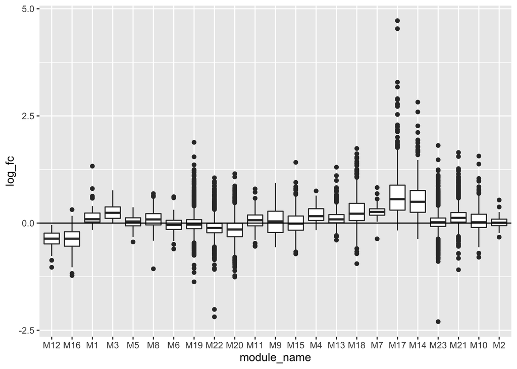

```r
module_gsea <- gene_modules %>%
  select(termid = module, gene = genename)

load(file = here::here("data/differential_expression/ALS/ALS_Spinal_Cord_de_res_Mar2022.RData"))

gene_sets_tstat <-
  map(de_res_final, ~{

    .x <- arrange(.x, desc(t) ) %>% filter(genename %in% module_gsea$gene)
    tstat <- .x$t
    names(tstat) <- .x$genename
    return(tstat)
  })

gene_sets_lfc <-
  map(de_res_final, ~{
    .x <-
      .x %>%
      filter(p_value < 0.05) %>%
      arrange(desc(log_fc) ) %>% filter(genename %in% module_gsea$gene)
    lfc <- .x$log_fc
    names(lfc) <- .x$genename
    return(lfc)
  })

module_gsea_res <- map_df(gene_sets_lfc, ~{
  as.data.frame(GSEA(.x, TERM2GENE = module_gsea,pvalueCutoff = Inf))
}, .id = "set")
gsea_plot <-
  module_gsea_res %>%
  full_join(colour_df, by = c("Description" = "module")) %>%
  mutate(label = ifelse(p.adjust < 0.05, "*", "")) %>%
  ggplot(aes(x = module_name, y = set, fill = NES)) +
  geom_tile(colour = "black") +
  geom_text( colour = "white", aes(label = label), nudge_y = -0.2) +
  scale_fill_distiller(na.value = "lightgray", palette = "RdBu") +
  scale_x_discrete(expand = c(0,0)) +
  scale_y_discrete(expand = c(0,0)) +
  labs(x = "", y = "") +
  facet_wrap(~1) +
  #scale_fill_manual(values = c("white", "red")) +
  theme(axis.line = element_blank(),
        strip.text = element_blank(),
        panel.border = element_rect(size = 0.6, colour = "black", fill = NA),
        axis.text.x = element_blank(),
        axis.text.y = element_text(colour = "black"),
        axis.ticks.x = element_blank(),
        legend.key.size = unit(0.25, 'cm'),
        legend.title = element_text(size = 5),
        legend.text = element_text(size =5),
        plot.margin = margin() )

##
module_gsea %>%
  left_join(colour_df, by = c("termid" = "module")) %>%
  #filter(module_name == "M3") %>%
  left_join(de_res_final$CSC, by = c("gene" = "genename")) %>%
  ggplot(aes(x = module_name, y = log_fc )) + geom_boxplot() +
  geom_hline(yintercept = 0)
```

The module clustering correlates well with whether the genes in those modules were upregulated or downregulated in ALS vs control. Despite there not being any control samples in the analysis.

## NEW - correlate MEs with cell-type proportions

```r
de_support <- read_tsv(here::here("data/differential_expression/ALS/ALS_all_differential_expression_support.tsv"))  %>%
  mutate(duration = as.numeric(duration))
```

```r
mathys_music_resid <- read_tsv(here::here("data/deconvolution/Mathys_MuSiC_residual_results.tsv"))

conversion_table <- data.frame(short = c("Ast","End", "Mic", "Ex", "Oli", "Per" ),
                               long = c("Astrocytes", "Endothelial", "Microglia", "Neurons", "Oligos", "Pericytes")
  )

deconv_df <- mathys_music_resid  %>%
  select(sample, cell, deconv) %>%
  left_join(conversion_table, by = c("cell" = "short")) %>%
  select(sample, cell = long, deconv)

support_deconv <-
  deconv_df %>%
  drop_na() %>%
  pivot_wider(names_from = cell, values_from = deconv) %>%
  column_to_rownames(var = "sample")

support_deconv <- support_deconv[ row.names(support_onehot),]

deconv_me <-
  trait_assoc(model, return_object = TRUE, support_loc = support_deconv) %>%
  #left_join(trait_df, by = "trait") %>%
  left_join(module_names, by = "module") %>%
  #filter( !is.na(trait_label)  ) %>%
  mutate(padj = p.adjust(p.value, method = "bonferroni")) %>%
  select(module, module_name, n, trait_label = trait, correlation, p.value, padj) %>%
  arrange(padj)

m2_deconv_plot <- trait_plot(deconv_me, traits = unique(deconv_df$cell))


deconv_multiplot <-
dendro_plot /
  colour_plot /
  m2_mathys_plot /
  m2_deconv_plot /
(
  module_trait_plot("M8","Astrocytes",  traits = support_deconv, "% Astrocytes") |
  module_trait_plot("M9", "Endothelial", traits = support_deconv,"% Endothelial")
  ) /
( module_trait_plot("M17", "Microglia", traits = support_deconv,"% Microglia") |
 module_trait_plot(m = "M20", trait = "Neurons", traits = support_deconv, "% Neurons") ) /
(module_trait_plot(m = "M12", trait = "Oligos", traits = support_deconv, "% Oligodendrocytes") |
  module_trait_plot("M15", "Pericytes", traits = support_deconv,"% Pericytes")
) +
  plot_layout(nrow = 7, ncol = 1, heights = c(2,1,6,6,3,3,3))

ggsave(deconv_multiplot, filename = "ALS_SC/plots/WGCNA_module_deconv_multiplots.png", width = 6, height = 7, dpi = 600)
  #&
 # scale_x_continuous(labels = scales::percent_format(accuracy = 1,trim = FALSE)) & plot_layout(ncol = 3, nrow = 2))
```

Model 2 - voom normalised , batch and technical metrics removed

41 modules 28 modules have at least 1 KEGG term (70%), 39 with at least 1 GO BP term duration and tissue have most associations, motor onset and disease_C9 have none that pass multiple testing. One module is associated with age. - cyan and skyblue posiively associated w duration, cyan is enriched in astrocyte markers - orangered4 and green negatively associate w duration, both enriched in microglia - yellow is associated with tissue (higher in CSC) highly enriched with oligo terms - yellow is higher in men - darkslateblue and turquoise both altered between tissues, both enriched with neuron markers

This suggests that patients with longer disease duration have lower microglia and higher astrocyte as proportions It also suggests that the cell composition between ALS Cervical and Lumbar spinal cord is different, with more neurons and fewer microglia and oligodendrocytes in the LSC.

Using neuroexpresso markers instead of Kelley: mostly the same results, ivory and darkslateblue no longer significant.

Activation markers: green and orangered4 (microglia marker enriched) also enriched for microglia activation - no obvious separate activation module for microglia, although Plum1 is very strongly enriched for disease-associated microglia but is not itself associated with any trait. astrocyte activation is enriched in red and orangered4

Model 3 - voom normalized, SVA-network with a bunch of SVs

- 68 modules, 40 with KEGG terms.

some modules are correlated with RIN, one strongly with sex, very litle with age, onset. Some modulesa associate with C9orf72.

- Microglia modules: pink, navajowhite2, darkolivegreen
- Astrocyte modules: darkolivegreen, navajo white, plum1, orange, steelblue, darkorange - astro and micro have overlapping modules!
- Neuron modules - lots - darkseagreen, floralwhite, lightsteelblue1
- Oligo modules: blue, plum, royalblue, red
- Tissue effects: floralwhite and green - neither enriched with cell type, nor with KEGG terms
- Sex affects: floralwhite, green and honeydew1 - same as above